# FigureYa81immune_network

**Author(s)**: Dongqiang Zeng, Taojun Ye  
**Reviewer(s)**: Ying Ge  
**Date**: `r Sys.Date()`

# Academic Citation

If you use this code in your work or research, we kindly request that you cite our publication:

Xiaofan Lu, et al. (2025). FigureYa: A Standardized Visualization Framework for Enhancing Biomedical Data Interpretation and Research Efficiency. iMetaMed. https://doi.org/10.1002/imm3.70005

## 需求描述

复现原文免疫细胞之间相关性的网络图

## Requirement description

Reproduce the network diagram of the correlation between immune cells in the original text

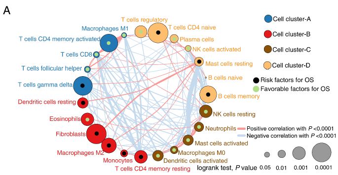

出自http://cancerimmunolres.aacrjournals.org/content/early/2019/03/06/2326-6066.CIR-18-0436

fromhttp://cancerimmunolres.aacrjournals.org/content/early/2019/03/06/2326-6066.CIR-18-0436

节点的颜色代表细胞所属的cluster，节点的大小代表生存分析的log_rank_p，用圆心点的颜色展示HR，连线颜色代表正/负相关，连线的粗细代表相关性Pvalue。

The color of the node represents the cluster to which the cell belongs, the size of the node represents the log_rank_p of survival analysis, HR is displayed using the color of the center point, the color of the connecting line represents positive/negative correlation, and the thickness of the connecting line represents correlation Pvalue.

## 应用场景

用网络图同时展示相关关系、pvalue、聚类/分类结果、跟预后的关系。

- 例如例文中各细胞之间的相关关系、跟预后的关系
- 或表达谱数据中多个基因的相关性、聚类结果、pvalue、跟预后的关系，比FigureYa37correlation更丰富。

**画法说明：**

- 用代码画出例图中除圆心以外的部分。
- 再根据“output_HR_corlor.csv”的最后一列，用Illustrator在圆心上画点，点的颜色代表HR的正负。
- 最后输出的pdf文件是矢量图，可以用Illustrator等软件调整细胞名等文字的位置。

## Application scenarios

Using a network diagram to simultaneously display relevant relationships pvalue、 The relationship between clustering/classification results and prognosis.

-For example, the correlation between cells in the example text and their relationship with prognosis -Or the correlation and clustering results of multiple genes in the expression profile data pvalue、 The relationship with prognosis is richer than the correlation shown in Figure Ya37.

**Painting Description:**

-Draw the parts of the example diagram except for the center using code. -Based on the last column of ‘outputting _ HR-color. csv’, use Illustrator to draw a point on the center of the circle, with the color of the point representing the positive or negative sign of HR. -The final output PDF file is a vector image, which can be adjusted using software such as Illustrator to position text such as cell names.

## Environment settings

```r
source("install_dependencies.R")
```

```
## Starting R package installation...
## ===========================================
##
## Installing CRAN packages...
## Package already installed: corrplot
## Package already installed: igraph
## Package already installed: plyr
## Package already installed: reshape2
##
## ===========================================
## Package installation completed!
## You can now run your R scripts in this directory.
```

```r
# 加载数据处理和可视化所需的包 | Load packages for data processing and visualization
library(reshape2)     # 用于数据重塑 | For data reshaping
library(corrplot)     # 用于绘制相关性热图 | For correlation matrix visualization
library(plyr)         # 用于数据操作和聚合 | For data manipulation and aggregation
library(igraph)       # 用于绘制网络图 | For network graph visualization
# 设置环境和选项 | Set environment and options
Sys.setenv(LANGUAGE = "en")           # 设置显示英文报错信息 | Set error messages to English
options(stringsAsFactors = FALSE)     # 禁止将字符型变量自动转换为因子 | Disable automatic conversion of strings to factors
```

## Parameter settings

```r
# 定义网络图中连线的颜色 | Define colors for edges in network graph
poscol <- "#FB9A99"  # 正相关用红色连线 | Red color for positive correlations
negcol <- "#C6DBEF"  # 负相关用蓝色连线 | Blue color for negative correlations

# 定义聚类的颜色方案 | Define color palette for clusters
mycol <- c("#FDBF6F", "#1F78B4", "#E31A1C", "#8C510A")
# 用于不同聚类的颜色，如果有更多类，需要添加更多颜色 | Colors for different clusters, add more if needed
```

## 输入文件

至少要提供easy_input_immune.csv文件，例如免疫细胞矩阵，或基因表达矩阵（把这里的免疫细胞替换成基因即可）。如果没有生存分析结果，可以用其他pvalue代替。

easy_input_immune.csv，免疫细胞矩阵文件，用于计算相关系数和P值、把细胞分成4个cluster、通过卡相关性的P值来建立细胞间的连接关系。每行一个sample，每列一种细胞。最后一列fibioblast用mcpcounter获得，可参考FigureYa56immune_inflitration；文中其他22种免疫细胞用CIBERSORT计算获得，还可以用FigureYa56immune_inflitration或FigureYa71ssGSEA来量化免疫细胞。

easy_input_HR.csv，生存分析结果，需要HR（节点圆心点的颜色，用AI来加）和p value（节点圆的大小）列。可通过FigureYa47HR2table计算获得。

## Input file

At least provide the easy_input_immune.csv file, such as the immune cell matrix or gene expression matrix (replace the immune cells here with genes). If there are no survival analysis results, other p-values can be used instead.

easy_input_immune.csv， Immune cell matrix file, used to calculate correlation coefficients and P-values, divide cells into 4 clusters, and establish intercellular connections through P-values of card correlation. One sample per row, one cell per column. The last column of fibioblast can be obtained using mcpcounter, as shown in Figure Ya56immune_inflation; The other 22 types of immune cells in the article were calculated using CIBERSORT, and can also be quantified using FigureYa56immune-inflammation or FigureYa71ssGSEA.

easy_input_HR.csv， The survival analysis results require columns for HR (color of node center point, added by AI) and p-value (size of node circle). It can be calculated using FigureYa47HR2table.

```r
# 读取免疫细胞表达矩阵数据 | Read immune cell expression matrix data
input_data <- read.csv("easy_input_immune.csv", row.names = 1, check.names = F)
dim(input_data)                  # 查看数据维度 | Check data dimensions
```

```
## [1] 1991   23
```

```r
input_data[1:3,1:3]              # 显示数据前几行几列 | Preview data structure
```

```
##     B cells naive B cells memory Plasma cells
## 804    -0.8497752      1.4181238  -0.54757209
## 805     0.4770200      1.2419958   0.30147166
## 806    -0.2558564     -0.8757098   0.01523679
```

```r
# 读取生存分析结果数据 | Read survival analysis results
bb <- read.csv("easy_input_HR.csv", header = T)
head(bb)                         # 查看数据前几行 | Preview data
```

```
##                  Cell.types    HR CI_up CI_low log_rank_p  fraction
## 1            B cells memory 1.451 1.243  1.693   1.96e-06  3.409351
## 2             B cells naive 1.039 0.807  1.337   7.64e-01  1.048245
## 3 Dendritic cells activated 0.714 0.560  0.910   6.11e-03  4.025877
## 4   Dendritic cells resting 1.283 1.102  1.493   1.25e-03  1.491400
## 5               Eosinophils 0.660 0.568  0.768   5.17e-08  3.816987
## 6               Fibroblasts 1.531 1.318  1.778   1.88e-08 14.320000
```

```r
bb$Cell.types <- as.character(bb$Cell.types)  # 将细胞类型转为字符型 | Convert cell types to character
colnames(bb)[1] <- c("ID")       # 重命名第一列为ID | Rename first column to "ID"

# 数据预处理：计算节点属性 | Data preprocessing: Calculate node attributes
bb$weight <- abs(log10(bb$log_rank_p))        # 用log-rank p值的对数绝对值表示节点大小 | Node size by -log10(p-value)
bb$weight_HR <- (as.numeric(bb$HR)-1)*100     # 将HR值转换为可用于着色的值 | Transform HR for coloring
bb$colr <- ifelse(bb$weight_HR<0, "green", "black")  # 根据HR值设置节点颜色：HR<1为绿色，否则为黑色 | Set node color by HR

head(bb)                         # 查看处理后的数据集 | Preview processed data
```

```
##                          ID    HR CI_up CI_low log_rank_p  fraction    weight
## 1            B cells memory 1.451 1.243  1.693   1.96e-06  3.409351 5.7077439
## 2             B cells naive 1.039 0.807  1.337   7.64e-01  1.048245 0.1169066
## 3 Dendritic cells activated 0.714 0.560  0.910   6.11e-03  4.025877 2.2139588
## 4   Dendritic cells resting 1.283 1.102  1.493   1.25e-03  1.491400 2.9030900
## 5               Eosinophils 0.660 0.568  0.768   5.17e-08  3.816987 7.2865095
## 6               Fibroblasts 1.531 1.318  1.778   1.88e-08 14.320000 7.7258422
##   weight_HR  colr
## 1      45.1 black
## 2       3.9 black
## 3     -28.6 green
## 4      28.3 black
## 5     -34.0 green
## 6      53.1 black
```

```r
# 保存处理后的生存分析结果到CSV文件 | Save processed survival analysis results to CSV
write.csv(bb, "output_HR_corlor.csv", quote = F)  # 输出用于后续绘图的带颜色信息的文件 | Output file with color info for plotting
```

## 相关性的计算

### 计算每两种细胞间的相关性

计算每两种细胞间的相关性corr，用corrplot可视化，看看聚成几类比较好。

## Calculation of correlation

### Calculate the correlation between every two types of cells

Calculate the correlation corr between every two types of cells, visualize it using corrplot, and see which categories are better clustered.

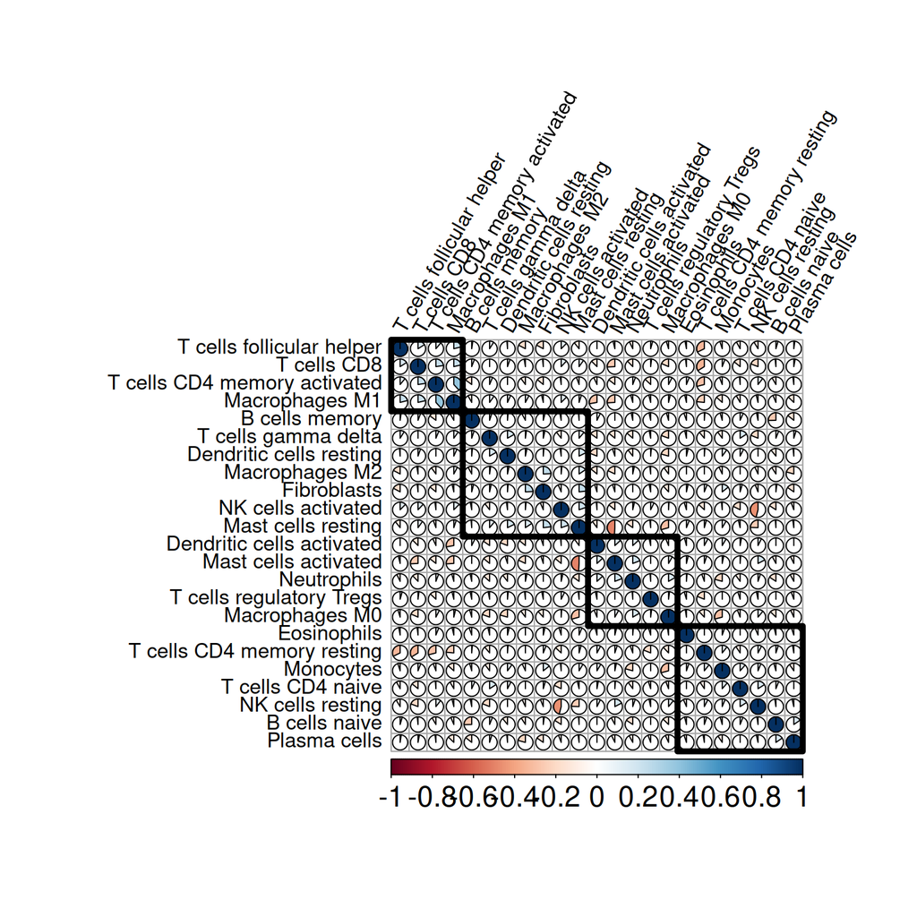

```r
# options(scipen = 100,digits = 4)  # 取消科学计数法显示，保留4位小数 | Disable scientific notation, show 4 decimal places

# 计算免疫细胞表达量之间的Spearman相关性矩阵 | Calculate Spearman correlation matrix between immune cell expressions
corr <- cor(input_data, method = "spearman")

# 绘制相关性热图 | Plot correlation heatmap
corrplot(corr, title = "",
         method = "pie",           # 可视化方法：饼图 (也可用"circle", "square"等) | Visualization method: pie chart
         outline = T,              # 显示单元格边框 | Show cell borders
         addgrid.col = "darkgray", # 添加网格线颜色 | Add grid line color
         order = "hclust",         # 按层次聚类排序 | Order by hierarchical clustering
         addrect = 4,              # 添加4个聚类矩形框 | Add 4 clustering rectangles
         mar = c(4,0,4,0),         # 调整边距使标签完整显示 | Adjust margins for label visibility
         rect.col = "black",       # 矩形框颜色 | Rectangle color
         rect.lwd = 5,             # 矩形框线宽 | Rectangle line width
         cl.pos = "b",             # 颜色图例位置：底部 | Color legend position: bottom
         tl.col = "black",         # 文本标签颜色 | Text label color
         tl.cex = 1.08,            # 文本标签大小 | Text label size
         cl.cex = 1.5,             # 颜色图例大小 | Color legend size
         tl.srt = 60)              # 文本标签旋转角度 | Text label rotation angle
```

### 计算相关性分析的P值

也可以用Hmsic包来求，但是发现它输出的P值有限制。

### Calculate the P-value for correlation analysis

It can also be calculated using the Hmsic package, but it was found that its output P value is limited.

```r
# 自定义函数：计算相关系数的p值矩阵 | Custom function: Calculate p-value matrix for correlation coefficients
cor.mtest <- function(corr, ...) {
  corr <- as.matrix(corr)          # 将输入转换为矩阵格式 | Convert input to matrix format
  n <- ncol(corr)                  # 获取矩阵列数（变量数量）| Get number of columns (variables)
  p.corr <- matrix(NA, n, n)       # 初始化p值矩阵 | Initialize p-value matrix
  diag(p.corr) <- 0                # 对角线元素（自身相关）p值设为0 | Set diagonal p-values to 0

  # 计算所有变量对之间的相关系数p值 | Calculate p-values for all variable pairs
  for (i in 1:(n - 1)) {
    for (j in (i + 1):n) {
      tmp <- cor.test(corr[, i],   # 执行Spearman相关性检验 | Perform Spearman correlation test
                      corr[, j],
                      method = "spearman", ...)
      p.corr[i, j] <- p.corr[j, i] <- tmp$p.value  # 对称填充p值矩阵 | Fill p-value matrix symmetrically
    }
  }

  colnames(p.corr) <- rownames(p.corr) <- colnames(corr)  # 设置矩阵行列名 | Set matrix row/column names
  p.corr  # 返回p值矩阵 | Return p-value matrix
}

# 计算免疫细胞表达量相关性的p值矩阵 | Calculate p-value matrix for immune cell correlations
p.corr <- cor.mtest(input_data)
head(p.corr[, 1:5])  # 显示p值矩阵的前几行和前5列 | Show first few rows and 5 columns of p-value matrix
```

```
##                            B cells naive B cells memory Plasma cells
## B cells naive               0.000000e+00   1.267844e-30 3.849669e-12
## B cells memory              1.267844e-30   0.000000e+00 1.248908e-10
## Plasma cells                3.849669e-12   1.248908e-10 0.000000e+00
## T cells CD8                 4.610780e-01   1.036536e-02 1.934684e-01
## T cells CD4 naive           7.676037e-03   2.571767e-03 9.528199e-01
## T cells CD4 memory resting  2.104157e-02   5.587199e-01 2.407682e-01
##                             T cells CD8 T cells CD4 naive
## B cells naive              4.610780e-01      7.676037e-03
## B cells memory             1.036536e-02      2.571767e-03
## Plasma cells               1.934684e-01      9.528199e-01
## T cells CD8                0.000000e+00      1.796709e-10
## T cells CD4 naive          1.796709e-10      0.000000e+00
## T cells CD4 memory resting 1.412504e-54      2.579735e-05
```

### 计算节点间的连接关系

只保留那些相关性较强的连接

### Calculate the connection relationship between nodes

Only retain connections with strong correlation

```r
# 合并相关系数矩阵和P值矩阵 | Merge correlation coefficients and p-values
rr <- as.data.frame(corr)         # 将相关系数矩阵转换为数据框 | Convert correlation matrix to dataframe
rr$ID <- rownames(rr)             # 添加行名作为ID列 | Add row names as ID column
cor <- melt(rr, "ID", value.name = "cor")  # 重塑数据为长格式 | Reshape data to long format

pp <- as.data.frame(p.corr)        # 将P值矩阵转换为数据框 | Convert p-value matrix to dataframe
pp$ID <- rownames(pp)             # 添加行名作为ID列 | Add row names as ID column
pvalue <- melt(pp, "ID", value.name = "pvalue")  # 重塑数据为长格式 | Reshape data to long format
colnames(pvalue) <- c("from", "to", "pvalue")  # 重命名列 | Rename columns

corpvlue <- cbind(pvalue, cor)    # 合并相关性和P值数据 | Combine correlation and p-value data
head(corpvlue)
```

```
##                         from            to       pvalue
## 1              B cells naive B cells naive 0.000000e+00
## 2             B cells memory B cells naive 1.267844e-30
## 3               Plasma cells B cells naive 3.849669e-12
## 4                T cells CD8 B cells naive 4.610780e-01
## 5          T cells CD4 naive B cells naive 7.676037e-03
## 6 T cells CD4 memory resting B cells naive 2.104157e-02
##                           ID      variable         cor
## 1              B cells naive B cells naive  1.00000000
## 2             B cells memory B cells naive -0.25373410
## 3               Plasma cells B cells naive  0.15475062
## 4                T cells CD8 B cells naive -0.01652791
## 5          T cells CD4 naive B cells naive  0.05973225
## 6 T cells CD4 memory resting B cells naive  0.05170576
```

```r
corpvlue <- corpvlue[, -c(4:5)]   # 删除重复的ID列 | Remove redundant ID columns
head(corpvlue)
```

```
##                         from            to       pvalue         cor
## 1              B cells naive B cells naive 0.000000e+00  1.00000000
## 2             B cells memory B cells naive 1.267844e-30 -0.25373410
## 3               Plasma cells B cells naive 3.849669e-12  0.15475062
## 4                T cells CD8 B cells naive 4.610780e-01 -0.01652791
## 5          T cells CD4 naive B cells naive 7.676037e-03  0.05973225
## 6 T cells CD4 memory resting B cells naive 2.104157e-02  0.05170576
```

```r
dim(corpvlue)                     # 查看数据维度 | Check data dimensions
```

```
## [1] 529   4
```

```r
# 筛选显著相关的连接 | Filter significant correlations
corpvlue <- corpvlue[corpvlue$pvalue < 0.0001, ]  # 保留p值小于0.0001的连接 | Keep only highly significant connections
dim(corpvlue)
```

```
## [1] 215   4
```

```r
# 计算连接权重（基于P值） | Calculate edge weights (based on p-values)
corpvlue$weight <- corpvlue$pvalue
corpvlue$weight <- -log10(corpvlue$weight)  # 转换为-log10(p)以增强显著性差异 | Transform to -log10(p) for better visualization
head(corpvlue)
```

```
##                  from            to       pvalue         cor    weight
## 1       B cells naive B cells naive 0.000000e+00  1.00000000       Inf
## 2      B cells memory B cells naive 1.267844e-30 -0.25373410 29.896934
## 3        Plasma cells B cells naive 3.849669e-12  0.15475062 11.414577
## 12 NK cells activated B cells naive 7.465376e-13 -0.15976916 12.126948
## 14     Macrophages M0 B cells naive 1.173912e-08 -0.12738044  7.930364
## 16     Macrophages M2 B cells naive 4.455440e-05 -0.09135948  4.351109
```

```r
# 数据清洗：移除自相关和重复连接 | Data cleaning: Remove self-correlations and duplicate edges
corpvlue <- corpvlue[!corpvlue$cor == 1, ]  # 移除完全相关（自身）的连接 | Remove self-correlations (cor=1)
dim(corpvlue)
```

```
## [1] 192   5
```

```r
# 移除重复连接 | Remove duplicate edges
summary(duplicated(corpvlue$weight))
```

```
##    Mode   FALSE    TRUE
## logical      96      96
```

```r
corpvlue <- corpvlue[!duplicated(corpvlue$weight), ]  # 保留唯一连接 | Keep unique edges only
dim(corpvlue)
```

```
## [1] 96  5
```

```r
# 根据相关系数方向设置连接颜色 | Set edge colors based on correlation direction
corpvlue$color <- ifelse(corpvlue$cor < 0, negcol, poscol)  # 负相关为蓝色，正相关为红色 | Negative: blue, Positive: red

# 保存处理后的连接数据到CSV文件 | Save processed edge data to CSV
write.csv(corpvlue, "output_links.csv")  # 输出用于网络图的连接数据 | Output edge data for network visualization
```

## 利用矩阵文件进行细胞的聚类

细胞聚类的结果综合考虑了”hclust”的结果、“kmeans”聚类的结果、以及目前的研究现状

## Cluster cells using matrix files

The results of cell clustering comprehensively consider the results of “hcluster”, “k-means” clustering, and the current research status

```r
# 转置数据用于聚类分析 | Transpose data for clustering analysis
cellcluster <- as.data.frame(t(input_data))  # 转置免疫细胞表达矩阵 | Transpose immune cell expression matrix
# cellcluster[1:5,1:5]  # 查看数据前几行几列 | Preview data structure

# 执行层次聚类分析 | Perform hierarchical clustering
hc <- hclust(dist(cellcluster))  # 计算距离矩阵并进行层次聚类 | Calculate distance matrix and perform hierarchical clustering
hcd <- as.dendrogram(hc)  # 将聚类结果转换为树状图对象 | Convert clustering result to dendrogram
(clus4 <- cutree(hc, 4))  # 将树状图切割为4个聚类 | Cut dendrogram into 4 clusters
```

```
##                B cells naive               B cells memory
##                            1                            2
##                 Plasma cells                  T cells CD8
##                            1                            1
##            T cells CD4 naive   T cells CD4 memory resting
##                            1                            3
## T cells CD4 memory activated    T cells follicular helper
##                            1                            2
##     T cells regulatory Tregs          T cells gamma delta
##                            2                            1
##             NK cells resting           NK cells activated
##                            4                            2
##                    Monocytes               Macrophages M0
##                            3                            4
##               Macrophages M1               Macrophages M2
##                            1                            3
##      Dendritic cells resting    Dendritic cells activated
##                            1                            4
##           Mast cells resting         Mast cells activated
##                            3                            4
##                  Eosinophils                  Neutrophils
##                            1                            4
##                  Fibroblasts
##                            3
```

```r
# 获取每个聚类中的细胞名称 | Extract cell names in each cluster
A <- as.character(rownames(as.data.frame(subset(clus4, clus4==1))))  # 聚类1的细胞 | Cells in cluster 1
B <- as.character(rownames(as.data.frame(subset(clus4, clus4==2))))  # 聚类2的细胞 | Cells in cluster 2
C <- as.character(rownames(as.data.frame(subset(clus4, clus4==3))))  # 聚类3的细胞 | Cells in cluster 3
D <- as.character(rownames(as.data.frame(subset(clus4, clus4==4))))  # 聚类4的细胞 | Cells in cluster 4
cls <- list(A, B, C, D)  # 将所有聚类结果存入列表 | Store all clusters in a list

# 创建节点数据框并指定聚类标签 | Create node dataframe and assign cluster labels
nodes <- as.data.frame(unlist(cls))  # 将聚类结果展平为数据框 | Flatten cluster list into dataframe
nodes$type <- c(rep("B", 9), rep("A", 4), rep("C", 5), rep("D", 5))  # 为每个细胞分配聚类类型 | Assign cluster types to cells
names(nodes) <- c("media", "type.label")  # 重命名列名 | Rename columns

# 基于领域知识手动调整部分细胞的聚类归属 | Manually adjust cluster assignments based on domain knowledge
nodes$type.label[nodes$media == "T cells follicular helper"] <- "B"  # 调整T细胞滤泡辅助细胞的聚类 | Adjust T follicular helper cells
nodes$type.label[nodes$media == "B cells naive"] <- "A"  # 调整幼稚B细胞的聚类 | Adjust naive B cells
nodes$type.label[nodes$media == "T cells CD4 naive"] <- "A"  # 调整幼稚CD4+T细胞的聚类 | Adjust naive CD4+ T cells
nodes$type.label[nodes$media == "Plasma cells"] <- "A"  # 调整浆细胞的聚类 | Adjust plasma cells
nodes$type.label[nodes$media == "Dendritic cells resting"] <- "C"  # 调整静息树突状细胞的聚类 | Adjust resting dendritic cells
nodes$type.label[nodes$media == "Eosinophils"] <- "C"  # 调整嗜酸性粒细胞的聚类 | Adjust eosinophils
nodes$type.label[nodes$media == "Mast cells resting"] <- "A"  # 调整静息肥大细胞的聚类 | Adjust resting mast cells

# 数据类型转换和检查 | Data type conversion and validation
nodes <- as.data.frame(nodes)  # 确保数据为数据框格式 | Ensure data is in dataframe format
nodes$media <- as.character(nodes$media)  # 将细胞名称转换为字符型 | Convert cell names to character type
nodes  # 显示最终节点数据 | Display final node data
```

```
##                           media type.label
## 1                 B cells naive          A
## 2                  Plasma cells          A
## 3                   T cells CD8          B
## 4             T cells CD4 naive          A
## 5  T cells CD4 memory activated          B
## 6           T cells gamma delta          B
## 7                Macrophages M1          B
## 8       Dendritic cells resting          C
## 9                   Eosinophils          C
## 10               B cells memory          A
## 11    T cells follicular helper          B
## 12     T cells regulatory Tregs          A
## 13           NK cells activated          A
## 14   T cells CD4 memory resting          C
## 15                    Monocytes          C
## 16               Macrophages M2          C
## 17           Mast cells resting          A
## 18                  Fibroblasts          C
## 19             NK cells resting          D
## 20               Macrophages M0          D
## 21    Dendritic cells activated          D
## 22         Mast cells activated          D
## 23                  Neutrophils          D
```

## 构建网络的input文件

## Build the input file for the network

```r
# 合并生存分析数据和细胞分类数据 | Merge survival analysis data and cell classification data
summary(nodes$media %in% bb$ID)  # 检查细胞名称是否一致 | Check if cell names match between datasets
```

```
##    Mode    TRUE
## logical      23
```

```r
nodes <- merge(nodes, bb, by.x = "media", "ID", all.x = T, all.y = T)  # 按细胞名合并数据 | Merge datasets by cell name

# 准备节点属性 | Prepare node attributes
nodes$Fraction <- abs(nodes$weight_HR)  # 计算节点大小属性（HR值的绝对值）| Node size based on absolute HR value
nodes$id <- paste("S", 01:23, sep = "")  # 为每个细胞分配唯一ID | Assign unique IDs to cells
nodes <- nodes[order(nodes$type.label),]  # 按细胞类型排序 | Sort by cell type
nodes <- nodes[,c(ncol(nodes),1:ncol(nodes)-1)]  # 调整列顺序，ID列为第一列 | Reorder columns, ID first
nodes <- nodes[order(nodes$type.label),]  # 再次按细胞类型排序 | Sort again by cell type
nodes  # 显示节点数据 | Display node data
```

```
##     id                        media type.label    HR CI_up CI_low log_rank_p
## 1   S1               B cells memory          A 1.451 1.243  1.693   1.96e-06
## 2   S2                B cells naive          A 1.039 0.807  1.337   7.64e-01
## 11 S11           Mast cells resting          A 1.238 1.063  1.443   6.06e-03
## 14 S14           NK cells activated          A 0.841 0.724  0.976   2.26e-02
## 16 S16                 Plasma cells          A 0.779 0.666  0.911   1.75e-03
## 19 S19            T cells CD4 naive          A 1.535 1.297  1.817   4.82e-07
## 23 S23     T cells regulatory Tregs          A 0.674 0.536  0.849   7.32e-04
## 8   S8               Macrophages M1          B 0.861 0.740  1.001   5.14e-02
## 17 S17 T cells CD4 memory activated          B 0.525 0.418  0.659   1.61e-08
## 20 S20                  T cells CD8          B 0.834 0.699  0.996   4.51e-02
## 21 S21    T cells follicular helper          B 0.837 0.716  0.979   2.55e-02
## 22 S22          T cells gamma delta          B 1.507 1.297  1.752   6.67e-08
## 4   S4      Dendritic cells resting          C 1.283 1.102  1.493   1.25e-03
## 5   S5                  Eosinophils          C 0.660 0.568  0.768   5.17e-08
```

[output cut: 33 more lines]

```r
# 建立细胞名与ID的映射关系 | Create mapping between cell names and IDs
paste0("'",nodes$media,"'","=","'",nodes$id,"'",collapse = ",")
```

```
## [1] "'B cells memory'='S1','B cells naive'='S2','Mast cells resting'='S11','NK cells activated'='S14','Plasma cells'='S16','T cells CD4 naive'='S19','T cells regulatory Tregs'='S23','Macrophages M1'='S8','T cells CD4 memory activated'='S17','T cells CD8'='S20','T cells follicular helper'='S21','T…
```

```r
# 将连接数据中的细胞名替换为ID | Replace cell names with IDs in edge data
corpvlue$from <- revalue(corpvlue$from, c(
  'B cells memory'='S1', 'B cells naive'='S2', 'Dendritic cells activated'='S3',
  'Dendritic cells resting'='S4', 'Eosinophils'='S5', 'Fibroblasts'='S6',
  'Macrophages M0'='S7', 'Macrophages M1'='S8', 'Macrophages M2'='S9',
  'Mast cells activated'='S10', 'Mast cells resting'='S11', 'Monocytes'='S12',
  'Neutrophils'='S13', 'NK cells activated'='S14', 'NK cells resting'='S15',
  'Plasma cells'='S16', 'T cells CD4 memory activated'='S17',
  'T cells CD4 memory resting'='S18', 'T cells CD4 naive'='S19',
  'T cells CD8'='S20', 'T cells follicular helper'='S21',
  'T cells gamma delta'='S22', 'T cells regulatory Tregs'='S23'
))
```

```r
corpvlue$to <- revalue(corpvlue$to, c(
  'B cells memory'='S1', 'B cells naive'='S2', 'Dendritic cells activated'='S3',
  'Dendritic cells resting'='S4', 'Eosinophils'='S5', 'Fibroblasts'='S6',
  'Macrophages M0'='S7', 'Macrophages M1'='S8', 'Macrophages M2'='S9',
  'Mast cells activated'='S10', 'Mast cells resting'='S11', 'Monocytes'='S12',
  'Neutrophils'='S13', 'NK cells activated'='S14', 'NK cells resting'='S15',
  'Plasma cells'='S16', 'T cells CD4 memory activated'='S17',
  'T cells CD4 memory resting'='S18', 'T cells CD4 naive'='S19',
  'T cells CD8'='S20', 'T cells follicular helper'='S21',
  'T cells gamma delta'='S22', 'T cells regulatory Tregs'='S23'
))

links <- corpvlue  # 重命名连接数据 | Rename edge data

# 使用igraph包构建网络图 | Construct network graph using igraph package
net <- graph_from_data_frame(d = links, vertices = nodes, directed = T)
# 从数据框构建图对象：d为连接数据，vertices为节点数据，directed指定有向图 | Build graph: edges from 'links', nodes from 'nodes', directed graph
```

### Start drawing

```r
# 根据细胞聚类设置节点颜色 | Set node colors based on cell clusters
V(net)$color <- revalue(nodes$type.label, c("A"=mycol[1], "B"=mycol[2], "C"=mycol[3], "D"=mycol[4]))
# 将聚类标签映射为之前定义的颜色 | Map cluster labels to predefined colors

# 计算节点度并设置节点大小 | Calculate node degrees and set node sizes
V(net)$size <- (1 + V(net)$weight)*3  # 节点大小基于-log10(p值)，可根据数据调整 | Node size based on -log10(p-value), adjustable
V(net)$label <- V(net)$media  # 设置节点标签为细胞名称 | Set node labels to cell names

# 设置边的属性 | Set edge properties
E(net)$arrow.mode <- 0        # 无边箭头 | No arrowheads
E(net)$edge.color <- "tomato"  # 边的默认颜色 | Default edge color
E(net)$width <- 1 + E(net)$weight/6  # 边的宽度基于权重，即-log10(p值) | Edge width based on -log10(p-value)

# 输出网络图到PDF文件 | Export network graph to PDF
pdf("Immune_network.pdf", width = 9.75, height = 8.78)

# 绘制网络图 | Plot network graph
plot(net,
     layout = layout_in_circle,  # 圆形布局 | Circular layout
     edge.curved = 0.2,          # 边的弯曲度 | Edge curvature
     vertex.label.color = V(net)$color,  # 标签颜色与节点一致 | Label color matches node color
     vertex.label.dist = -2,     # 标签与节点的距离，负值表示外部 | Label distance from node
     edge.color = links$color)   # 边的颜色基于相关系数正负 | Edge color based on correlation direction

# 添加聚类图例 | Add legend for clusters
legend("topright",             # 图例位置：右上角 | Legend position: top-right
       c("Cell cluster-A", "Cell cluster-B", "Cell cluster-C", "Cell cluster-D"),
       pch = 21,               # 图例符号：实心圆带边框 | Legend symbol: filled circle with border
       col = "black",          # 边框颜色 | Border color
       pt.bg = mycol,          # 填充颜色 | Fill color
       pt.cex = 3,             # 符号大小 | Symbol size
       cex = 1.3,              # 文字大小 | Text size
       bty = "n",              # 无边框 | No box
       ncol = 1)               # 单列排列 | Single column

# 添加节点大小图例（基于P值） | Add legend for node size (based on p-values)
f <- c(0.05, 0.001, 0.00001, 0.00000001)  # 示例P值 | Example p-values
s <- abs(log10(f))  # 对应大小 | Corresponding sizes

legend("bottomright",
       inset = c(0, -0.1),     # 向下偏移 | Shift downward
       legend = f,             # 图例文字 | Legend text
       text.width = 0.2,       # 文字宽度 | Text width
       title = "logrank test, P value",  # 图例标题 | Legend title
       title.adj = -0.5,       # 标题位置调整 | Title position adjustment
       pch = 21,               # 符号类型 | Symbol type
       pt.cex = s,             # 符号大小 | Symbol size
       bty = 'n',              # 无边框 | No box
       horiz = TRUE)           # 水平排列 | Horizontal arrangement

# 添加边的图例（正负相关） | Add legend for edge colors (positive/negative correlations)
legend("bottomright",
       c("Positive correlation with P < 0.0001",
         "Negative correlation with P < 0.0001"),
       col = c(poscol, negcol),  # 颜色对应正负相关 | Colors for positive/negative correlations
       bty = "n",                # 无边框 | No box
       cex = 1,                  # 文字大小 | Text size
       lty = 1,                  # 线条类型 | Line type
       lwd = 5)                  # 线条宽度 | Line width

dev.off()  # 关闭图形设备 | Close graphics device
```

[figure not shown]

文字的位置用Illustrator调整；再根据“output_HR_corlor.csv”的最后一列用Illustrator在圆心上画点，点的颜色代表HR的正负。

Adjust the position of the text using Illustrator; Draw a point on the center of the circle using Illustrator based on the last column of ‘outputting _ HR-color. csv’, where the color of the point represents the positive or negative sign of HR.